# Custom PK models and TCI algorithms using the tci package

### Introduction

The `tci` package provides closed-form solutions for 1-, 2-, 3-, and 3-compartment with effect-site PK models based on solutions described and code provided in Abuhelwa, Foster, and Upton (2015). It does not, however, include an ordinary differential equation (ODE) solver as many other R packages do, including [mrgsolve](https://mrgsolve.org/), PKPDsim, and RxODE. `tci` package functions can nonetheless be applied to models from these packages through the creation of user-defined PK functions.

### Custom PK models

$$\begin{equation}\label{eq:remif}
\begin{aligned}
V_1 \cdot \frac{dC_p}{dt} &= -Cl_1 \cdot C_1 + k_{21}\cdot V_2
\cdot C_2 + k_{31}\cdot C_3 \cdot V_3 + -[(k_{12}+k_{13}+k_{10})\cdot
C_1] \cdot V_1 + k_R(t) \\
V_2 \cdot \frac{dC_2}{dt} &= k_{12} \cdot C_1 \cdot V_1 - k_{21}
\cdot C_2 \cdot V_2 - Cl_2 \cdot C_2 \\
V_3 \cdot \frac{dC_3}{dt} &= k_{13} \cdot C_1 \cdot V_1 - k_{31}
\cdot C_3 \cdot V_3 - Cl_3 \cdot C_3
\end{aligned}
\end{equation}$$

To implement the ODE system in `mrgsolve` we initialize a model using `mrgsolve::mcode` with default parameter values.

```r
library(tci)
library(mrgsolve) # implement ODE equation
library(xtable)   # printing tables
library(ggplot2)  # plotting results
library(reshape2) # melt function

form <- '
$PARAM V1 = 7.88, V2=23.9, V3=13.8, CL1=5, CL2=0.828, CL3=0.0784,
k10 = 0.172, k12=0.373, k21=0.103, k13=0.0367, k31=0.0124
$CMT A1 A2 A3
$ODE
dxdt_A1 = k21*A2 + k31*A3 - (k12+k13+k10)*A1 - CL1/V1*A1;
dxdt_A2 = k12*A1 - k21*A2 - CL2/V2*A2;
dxdt_A3 = k13*A1 - k31*A3 - CL3/V3*A3;
'
mrg_mod_remif <- mcode("remifentanil", form)
```

For a custom model to be compatible with PK, it must take as arguments 1) a vector of time points, `tm`, 2) an numeric value describing a constant infusion rate, `kR`, 3) a vector of PK parameter values, `pars`, and 4) initial starting concentrations, `init`. Notably, `init` should be created with default values, as `pkmod` will use the initial values to determine the number of compartments in the model.

```r
pk_remif <- function(tm, kR, pars, init = c(0,0,0)){

  # allow lowercase names
  names(pars) <- toupper(names(pars))
  # store volume
  vols <- pars[c("V1","V2","V3")]
  A0 <- init*vols # initial amounts
  names(A0) <- c("A1","A2","A3") # names required by mrgsolve

  # pass parameters as list
  pars <- sapply(pars, as.list)

  # update parameters and initial values (as amounts)
  mrg_mod_remif <- update(mrg_mod_remif, param = pars, init = A0)

  # dosing regimen - mrgsolve function in terms of amount infused
  event <- ev(amt =  kR*max(tm), time = 0, tinf = max(tm))

  # simulate responses (skip tm=0 unless specified)
  dat <- mrgsim_q(x = mrg_mod_remif, # pk model
                  data = event, # dosing event
                  stime = tm) # evaluation times

  # skip tm=0 unless specified in tm
  dat <- dat@data[-1,]

  # return concentrations with compartments in rows and times in columns
  cons <- t(dat[,c("A1","A2","A3")]) / vols

  rownames(cons) <- colnames(cons) <- NULL
  return(cons)
}
```

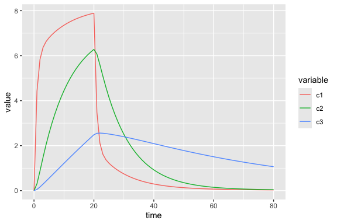

```r
dose_remi <- inf_manual(inf_tms = 0, inf_rate = 60, duration = 20)
pars_remif <- c(V1 = 7.88, V2=23.9, V3=13.8, CL1=5, CL2=0.828, CL3=0.0784,
                k10 = 0.172, k12=0.373, k21=0.103, k13=0.0367, k31=0.0124)
mod_remif <- pkmod(pkfn = pk_remif, pars_pk = pars_remif)
p1 <- predict(mod_remif, inf = dose_remi, tms = 0:80)
ggplot(melt(data.frame(time = 0:80, p1), id = "time"),
       aes(x = time, y = value, color = variable)) +
  geom_line()
```

### Custom TCI algorithms

The `tci` package implements the Jacobs and Shafer algorithms plasma- and effect-site targeting algorithms, respectively (Jacobs 1990; Shafer and Gregg 1992). These algorithms aim to reach the target concentrations as quickly as possible without overshooting the target. There may, however, be situations in which the speed of target attainment is not the only goal. In these cases, a user may wish to specify a different TCI algorithm.

An example of this is the algorithm proposed by Van Poucke, Bravo, and Shafer (2004) that limits the maximum percentage overshoot of the target in the central compartment. The motivation for this is that there may exist cases in which excessive plasma concentrations are associated with toxicity to the patient. Here, we construct a similar algorithm that limits the absolute, rather than the percentage, overshoot in the central compartment.

The required arguments for a custom algorithm are 1) a single numeric value specifying the target concentration, `Ct`, 2) a `pkmod` object created by `pkmod()`, 3) a single numeric value specifying the infusion duration, `dtm`, and 4) additional arguments that are passed to `update.pkmod` at the beginning of the algorithm. Argument (4) is used to update starting concentrations when the algorithm is iteratively applied in `inf_tci`.

```r
tci_plasma_lim <- function(Ct, pkmod, dtm = 1/6, maxrt = 1200,
                          lim_amt = 0.5, ecmpt = NULL, tmax_search = 20,
                          cetol = 0.05, cptol = 0.1, ...){

  pkmod <- update(pkmod,...)

  # if effect-site concentration is close to target,
  # switch to plasma targeting
  if(with(pkmod,(Ct - init[ecmpt]) / Ct <  cetol &
     (Ct - init[pcmpt])/Ct <= cptol))
    return(tci_plasma(Ct, pkmod = pkmod, dtm = dtm, maxrt = maxrt))

  # maximum tolerable plasma concentration
  Cp_max <- Ct + lim_amt

  # infusion required to reach Cp_max
  pinf <- tci_plasma(Ct = Cp_max, pkmod = pkmod, dtm = dtm, maxrt = maxrt)

  # Administer dtm-minute infusion
  unit_inf <- inf_manual(inf_tms = 0, inf_rate = pinf, duration = dtm)

  # Calculate maximum effect-site concentration
  CeP <- function(tm) predict(pkmod, inf = unit_inf, tms = tm)[,pkmod$ecmpt]
  Ce_max <- optimize(CeP, c(0,20), maximum = TRUE)$objective

  # if max Ce < Ct administer infusion to reach maximum target
  if(Ce_max <= Ct + cetol*Ct)
    infrt <- pinf
  else
    infrt <- tci_effect_only(Ct, pkmod, dtm, maxrt = maxrt)

  return(infrt)
}
```

We can now apply the algorithm directly to a `pkmod` object to calculate a single infusion rate.

```r
mod3ecpt <- pkmod(pars_pk = c(cl = 10, q2 = 2, q3 =20, v = 15, v2 = 30, v3 = 50, ke0 = 1.2))
tci_plasma_lim(Ct = 2, pkmod = mod3ecpt, lim_amt = 0.25)
```

```
#> [1] 240.0374
```

More usefully, however, we can pass the algorithm to `inf_tci` through the `custom_alg` argument and use it to calculate infusion rates required to reach a series of targets.

```r
# tci target concentrations
tci_targets <- cbind(value = c(1,2,2.5,2.5), time = c(0,3,7,10))
# calculate infusion schedule using plasma-limiting algorithm
plim_inf <- inf_tci(target_vals = c(1,2,2.5,2.5),
                    target_tms = c(0,3,7,10),
                    pkmod = mod3ecpt,
                    custom_alg = tci_plasma_lim,
                    lim_amt = 0.25)
head(plim_inf)
```

```
#>        begin     end  inf_rate Ct c1_start    c2_start   c3_start  c4_start
#> [1,] 0.00000 0.16667 133.35413  1     0.00 0.000000000 0.00000000 0.0000000
#> [2,] 0.16667 0.33333  38.27734  1     1.25 0.007317989 0.04308491 0.1236035
#> [3,] 0.33333 0.50000  36.74880  1     1.25 0.021033000 0.12082833 0.3275202
#> [4,] 0.50000 0.66667  35.31726  1     1.25 0.034597490 0.19356382 0.4944899
#> [5,] 0.66667 0.83333  33.97649  1     1.25 0.048013056 0.26161398 0.6312089
#> [6,] 0.83333 1.00000  32.72067  1     1.25 0.061281283 0.32528061 0.7431596
#>      c1_end      c2_end     c3_end    c4_end
#> [1,]   1.25 0.007317989 0.04308491 0.1236035
#> [2,]   1.25 0.021033000 0.12082833 0.3275202
#> [3,]   1.25 0.034597490 0.19356382 0.4944899
#> [4,]   1.25 0.048013056 0.26161398 0.6312089
#> [5,]   1.25 0.061281283 0.32528061 0.7431596
#> [6,]   1.25 0.074403741 0.38484609 0.8348308
```

For comparison, we calculate the infusion schedule associated with direct effect-site targeting.

```r
# effect-site targeting
eff_inf <- inf_tci(target_vals = c(1,2,2.5,2.5),
                    target_tms = c(0,3,7,10),
                   pkmod = mod3ecpt,
                   type = "effect")
```

We now can use the infusion schedule in `predict.pkmod` or `plot.pkmod` methods

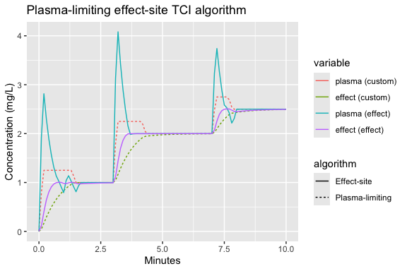

```r
# predict responses
tms_pred <- seq(0,10,0.1)
plim_pred <- predict(mod3ecpt, plim_inf, tms_pred)
eff_pred <- predict(mod3ecpt, eff_inf, tms_pred)

# plot results
dat <- data.frame(time = tms_pred,
                  `plasma (custom)` = plim_pred[,"c1"],
                  `effect (custom)` = plim_pred[,"c4"],
                  `plasma (effect)` = eff_pred[,"c1"],
                  `effect (effect)` = eff_pred[,"c4"],
                  check.names = FALSE)
datm <- melt(dat, id = "time")
datm$algorithm <- ifelse(datm$variable %in% c("plasma (custom)","effect (custom)"),
                         "Plasma-limiting", "Effect-site")
ggplot(datm, aes(x = time, y = value, color = variable, linetype = algorithm)) +
  geom_line() +
  xlab("Minutes") +
  ylab("Concentration (mg/L)") +
  ggtitle(label = "Plasma-limiting effect-site TCI algorithm")
```

### References

Abuhelwa, Ahmad Y., David J R Foster, and Richard N. Upton. 2015. “ADVAN-style analytical solutions for common pharmacokinetic models.” *Journal of Pharmacological and Toxicological Methods* 73: 42–48. https://doi.org/10.1016/j.vascn.2015.03.004.

Jacobs, James R. 1990. “Algorithm for Optimal Linear Model-Based Control with Application to Pharmacokinetic Model-Driven Drug Delivery.” *IEEE Transactions on Biomedical Engineering* 37 (1): 107–9. https://doi.org/10.1109/10.43622.

Shafer, Steven L., and Keith M. Gregg. 1992. “Algorithms to rapidly achieve and maintain stable drug concentrations at the site of drug effect with a computer-controlled infusion pump.” *Journal of Pharmacokinetics and Biopharmaceutics* 20 (2): 147–69. https://doi.org/10.1007/BF01070999.

Van Poucke, Guido E., Louis J Brandon Bravo, and Steven L. Shafer. 2004. “Target controlled infusions: Targeting the effect site while limiting peak plasma concentration.” *IEEE Transactions on Biomedical Engineering* 51 (11): 1869–75. https://doi.org/10.1109/TBME.2004.827935.